# dbplyr: dplyr for databases

R Pruim

July 2019

When working with databases, the data are stored on a server (typically a remote machine, but it could actually be on the same machine you are using for analysis). In order to access the data, you need to establish a **connection** to that server.

Here we demonstrate using public data from google’s bigquery service. You will need to activate an account, create a project, and enable billing for that project. (You won’t actualy be charged until you exceed the useage limits given for a free acount *and* agree to accept charges, so no worries about getting charged without being aware.) Find out more at https://github.com/r-dbi/bigrquery

```r
library(DBI)
library(bigrquery)
library(dplyr)

con <- dbConnect(
  bigrquery::bigquery(),
  project = "publicdata",
  dataset = "samples",
  billing = "dbplyr-examples" # set this to the name of a project that has billing enabled
)
con
```

```
## <BigQueryConnection>
##   Dataset: publicdata.samples
##   Billing: dbplyr-examples
```

Establishing a connection to other servers varies a bit from server to server, but generally you need to

- replace `bigrquery::bigquery()` with the appropriate function for the type of server you are using,
- provide authentication information (username and password).

Find out more about connecting to other types of SQL servers in the [dbplyr vignette](https://cran.r-project.org/web/packages/dbplyr/vignettes/dbplyr.html).

### Non-interactive use

For non-interactive use (like knitting this document), authorization must be achieved without user input via a web form. This can be acheived by creating an OAuth service account token. You create this online (see the [gargle API credentials vignette](https://gargle.r-lib.org/articles/get-api-credentials.html) for details), store the resulting JSON some where on your computer and use something like this to authenticate:

```r
# change patht to the location where you saved the token you downloaded from Google
bq_auth(path = "~/.R/gargle/my-bq-token.json")
```

## Step 2: Choose a table or tables

Databases generally consist of multiple **tables** of rectangular data. Let’s see what Google provides in their freely available example data sets and choose one to work with.

```r
# list the available data tables
dbListTables(con)   # you may be prompted to grant R access to your data
```

```
## [1] "github_nested"   "github_timeline" "gsod"            "natality"
## [5] "shakespeare"     "trigrams"        "wikipedia"
```

```r
# choose a table to work with
Natality <- tbl(con, "natality")
Natality %>% head()
```

```
## # Source:   lazy query [?? x 31]
## # Database: BigQueryConnection
##   source_year  year month   day  wday state is_male child_race
##         <int> <int> <int> <int> <int> <chr> <lgl>        <int>
## 1        1969  1969    11    29    NA KS    TRUE             1
## 2        1969  1969     2     6    NA MN    FALSE            1
## 3        1970  1970     9     4    NA LA    TRUE             1
## 4        1970  1970     1    24    NA NC    FALSE            1
## 5        1970  1970     6     6    NA SC    TRUE             2
## 6        1970  1970    10    30    NA VA    TRUE             1
## # … with 23 more variables: weight_pounds <dbl>, plurality <int>,
## #   apgar_1min <int>, apgar_5min <int>, mother_residence_state <chr>,
## #   mother_race <int>, mother_age <int>, gestation_weeks <int>, lmp <chr>,
## #   mother_married <lgl>, mother_birth_state <chr>, cigarette_use <lgl>,
## #   cigarettes_per_day <int>, alcohol_use <lgl>, drinks_per_week <int>,
## #   weight_gain_pounds <int>, born_alive_alive <int>,
## #   born_alive_dead <int>, born_dead <int>, ever_born <int>,
## #   father_race <int>, father_age <int>, record_weight <int>
```

## Step 3: Use dplyr just (about) as you would for a data frame

Sort version: `dplyr` converts your R code into SQL commands that are exectuted on the server.[^1]

Longer version:

- SQL queries to large data sets can be slow, so `dplyr` is very lazy and only grabs data when it needs to, and only a little bit (unless you ask for all of it with `collect()`).
- some things that you can do in R can’t be readily translated into the various flavors of SQL. So you might see some warnings if you try to do something `dplyr` can’t do what you want. Two important examples:
  - You can’t use `nrow()` or `tail()`. Each of these would be very expensive because they would require you to first compute the entire query.
  - `head()` does work and returns the first few rows of what the full query would have returned. (That’s also basically what happens unless you use `collect()` to get all of the data.) This allows you to test your query a bit before commiting to a potentially expensive operation that doesn’t do what you want.

```r
# Natality %>% head() returns a connection, not the actual data
Natality %>% head() %>% class()
```

```
## [1] "tbl_BigQueryConnection" "tbl_dbi"
## [3] "tbl_sql"                "tbl_lazy"
## [5] "tbl"
```

```r
# use collect to grab the data into local data frame
Natality %>% head() %>% collect() %>% class()
```

```
## [1] "tbl_df"     "tbl"        "data.frame"
```

```r
# from there we can query all the names in the data frame to see what variables there are
Natality %>% head() %>% collect() %>% names()
```

```
##  [1] "source_year"            "year"
##  [3] "month"                  "day"
##  [5] "wday"                   "state"
##  [7] "is_male"                "child_race"
##  [9] "weight_pounds"          "plurality"
## [11] "apgar_1min"             "apgar_5min"
## [13] "mother_residence_state" "mother_race"
## [15] "mother_age"             "gestation_weeks"
## [17] "lmp"                    "mother_married"
## [19] "mother_birth_state"     "cigarette_use"
## [21] "cigarettes_per_day"     "alcohol_use"
## [23] "drinks_per_week"        "weight_gain_pounds"
## [25] "born_alive_alive"       "born_alive_dead"
## [27] "born_dead"              "ever_born"
## [29] "father_race"            "father_age"
## [31] "record_weight"
```

Now lets calculate some summary information on the whole data set.

```r
Natality_Summary <-
  Natality %>%
  group_by(year, child_race, is_male) %>%
  summarise(
    n = n(),
    mean_wt = mean(weight_pounds, na.rm = TRUE)
  ) %>%
  arrange(year, child_race, is_male) %>%
  collect() %>%                                # fetch all of the data
  mutate(sex = ifelse(is_male, "M", "F"))
head(Natality_Summary)
```

```
## # A tibble: 6 x 6
## # Groups:   year, child_race [3]
##    year child_race is_male      n mean_wt sex
##   <int>      <int> <lgl>    <int>   <dbl> <chr>
## 1  1969          1 FALSE   727097    7.15 F
## 2  1969          1 TRUE    769710    7.42 M
## 3  1969          2 FALSE   134312    6.64 F
## 4  1969          2 TRUE    137254    6.88 M
## 5  1969          3 FALSE     5899    7.13 F
## 6  1969          3 TRUE      6105    7.33 M
```

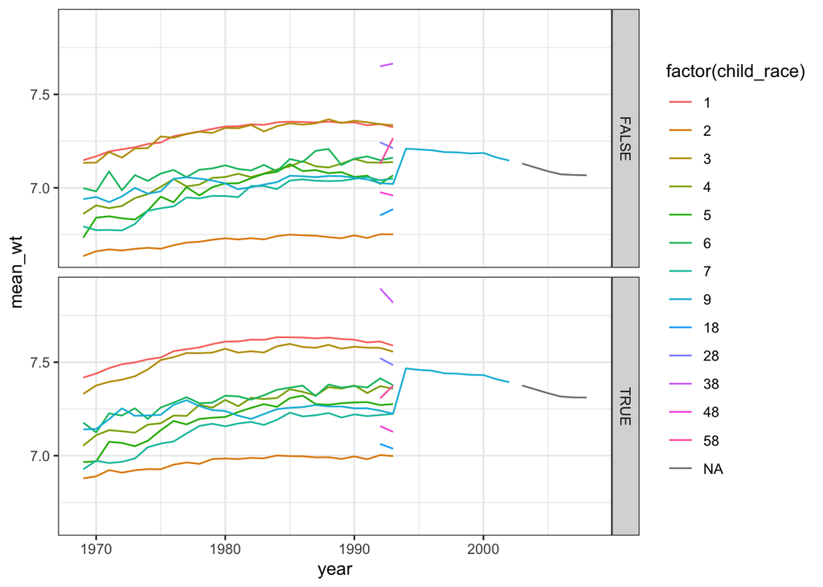

```r
library(ggformula)
Natality_Summary %>%
  gf_line(mean_wt ~ year | is_male ~ ., color = ~ factor(child_race))
```

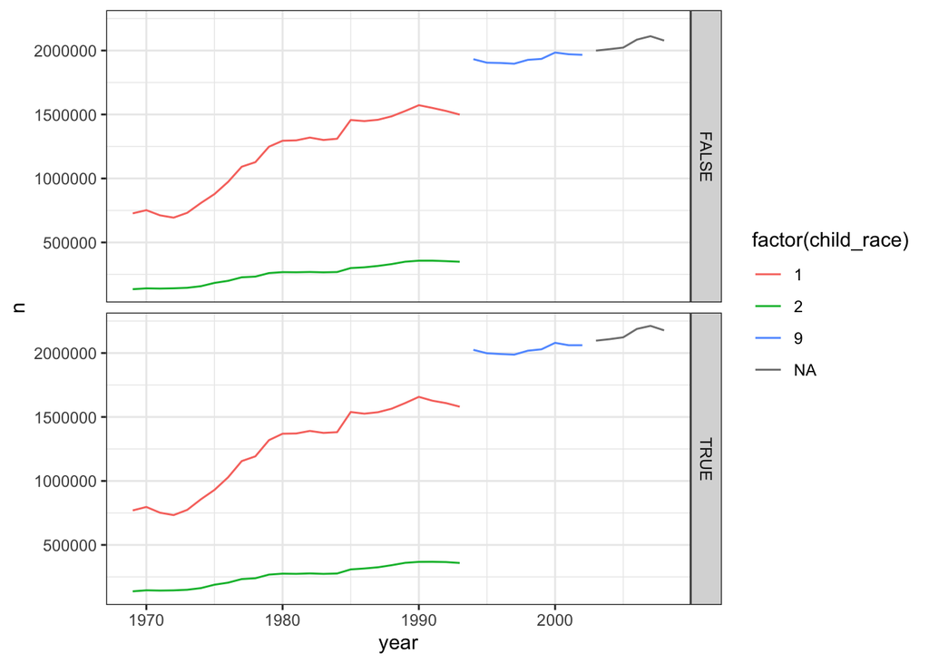

```r
Natality_Summary %>% filter(n > 50000) %>%
  gf_line(n ~ year | is_male ~ ., color = ~ factor(child_race))
```

## Where’s the code book?

You can find out at https://cloud.google.com/bigquery/public-data/.

[^1]: You can find out exactly what SQL is generated using `show_query()` or `explain()`.